## Life history parameters

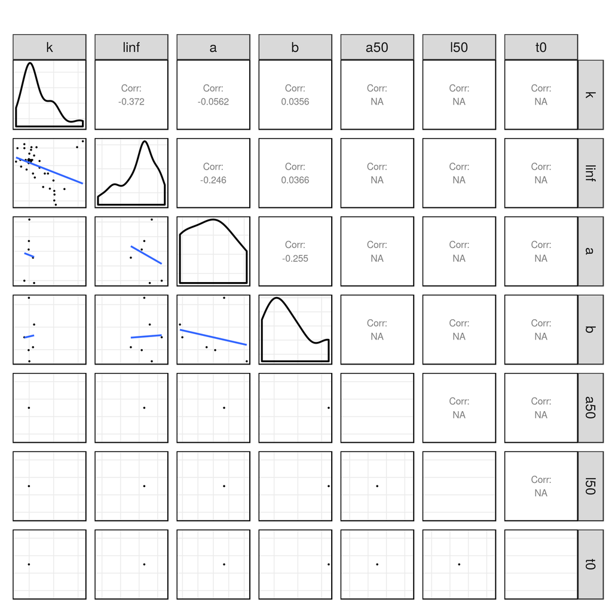

**Figure 1** Pairwise scatter plots of life history parameters.

## Equilibrium dynamics

The parameters are then used by `lhEql` to simulate the equilibrium dynamics by combining the spawner/yield per recruit relationships with a stock recruiment relationship.

[output not shown]

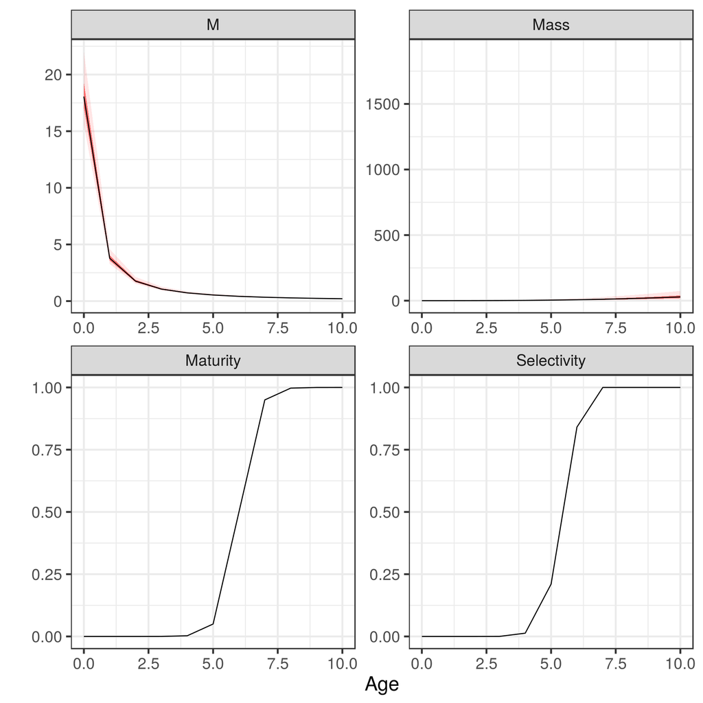

**Figure 2** Vectors.

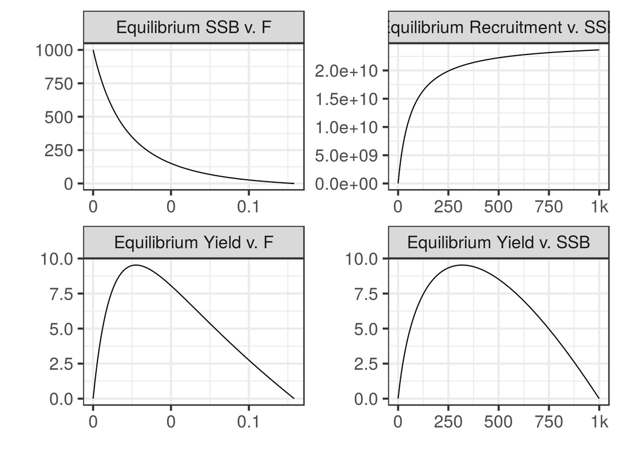

**Figure 3** Example equilibrum Curve.

## Population dynamics

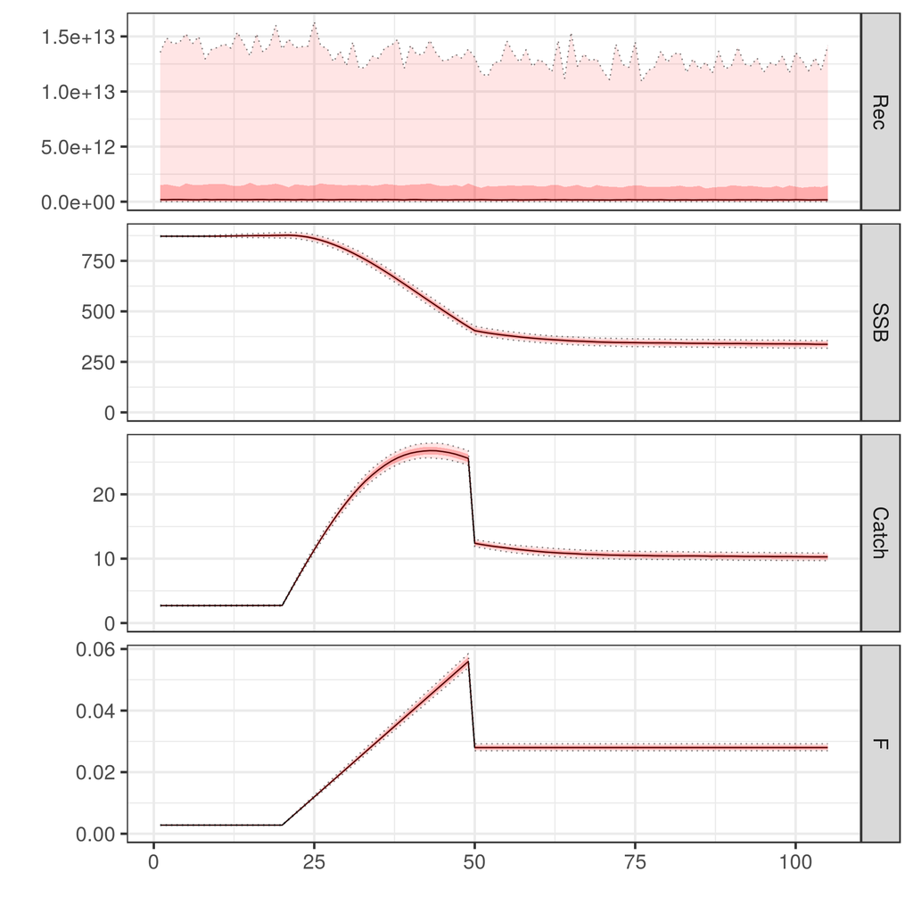

**Figure 4** Time series.

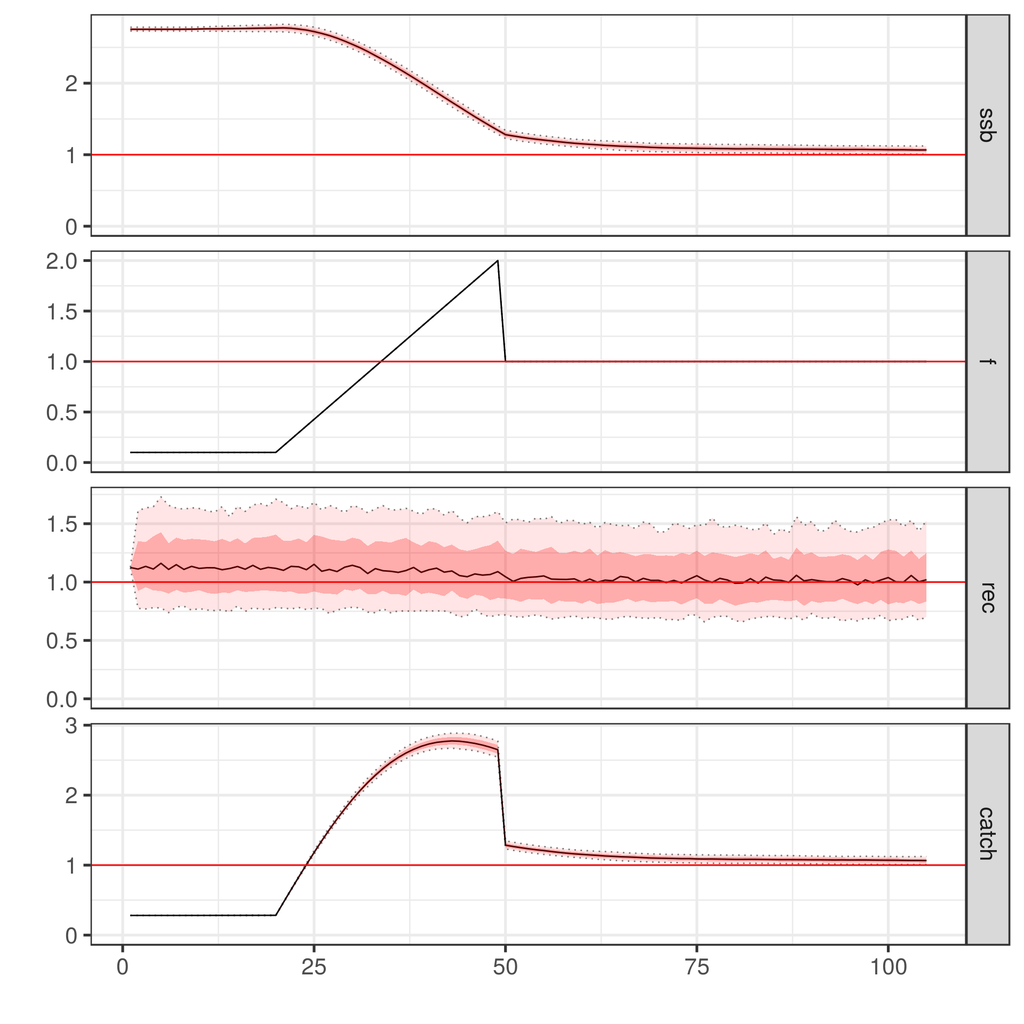

**Figure 5** Time series relative to MSY benchmarks.

## Software Versions

- R version 3.4.4 (2018-03-15)
- FLCore: 2.6.9.9009
- FLBRP: 2.5.3.9001
- FLasher: 0.5.0.9001
- FLife: 3.2.1.9001
- ggplotFL: 2.6.4.9002
- **Compiled**: Fri Nov 2 07:53:08 2018

## Author information

**Laurence Kell**. laurie@seaplusplus.es

## Acknowledgements

This vignette and many of the methods documented in it were developed under the MyDas project funded by the Irish exchequer and EMFF 2014-2020. The overall aim of MyDas is to develop and test a range of assessment models and methods to establish Maximum Sustainable Yield (MSY) reference points (or proxy MSY reference points) across the spectrum of data-limited stocks.